# 03072018 kinetic spec assay--temp trials

## setup

- *2.5 mg/mL A.P in H2O incubated at 53 and 60 degrees for 0,3,5 days.*
- *A.P diluted in H2O*
- hold concentration but vary time and temp
- Intended: 2.5 mg/mL A.P in H2O incubated at 50,55,60 degrees for 0,1,3,5 days.
  - Day 1 tubes pulled at day 5.
  - Actual temp was 53 and 60 deg C.
- 18 replicates-1=17 replicates
- no osmolytes

## objectives

- find temperature when A.P starts losing activity (last stable temp)
- amount of time A.P can be exposed to specific temp before it starts losing activity

## dilution

- calculate # of replicates $$ 4 days*3 temps/day*1rep/temp=12 reps$$
- vol per tube $$\frac{(75 uL 50mg/mL A.P +1425 uL H2O)}{12 tubes}$$
- vol in all tubes $$1500uL=12 reps*125 uL 2.5 mg/mL A.P/tube$$
- actual reps-1 (55 deg rep): $$17reps=3 days*3 temps/day*2 reps/temp-1 rep$$

| reagent | final concentration |
| --- | --- |
| 50 mM A.P @ -80 deg C | 2.5 mg/mL in H2O |
| PNPP | 50mg/mL in H2O |

## procedure

- prepare 12 screw cap tubes to contain protein. 1 tube per day,3 temps per day,4 days
- prepare 3 freezer boxes which will hold 4 tubes each. 1 box for each temperature (in oven)
- set 3 ovens, each to appropriate temperature. periodically record temperature
- each oven should be set to a specific temperature, should contain 1 freezer box which contains 4 (3) tubes
- however, do not actually put day 0 tubes in the boxes for incubation. store day 0 tubes in -20 deg C freezer immediately
- at each timepoint (day), pull appropriate tube from each box and store in -20 deg C freezer
- when all tubes have been taken out of incubation, measure protein activity in all tubes on that day.
- tubes from last timepoint do not need -20 deg C exposure when taken out of incubation

## raw velocity /min

| Time(day) | 50 (53.3 actual) deg | 55 (60 actual) deg | 60 deg |
| --- | --- | --- | --- |
| 0 | 2.4972 | 3.6966 | 3.0972 |
| 0 | 2.4276 | 2.2458 | 2.562 |
| 3 | .843 | .0927 | .1896 |
| 3 | .7578 | .07584 | .0819 |
| 5 | .7986 | .0447 | .014118 |
| 5 | .7308 |  | .027804 |

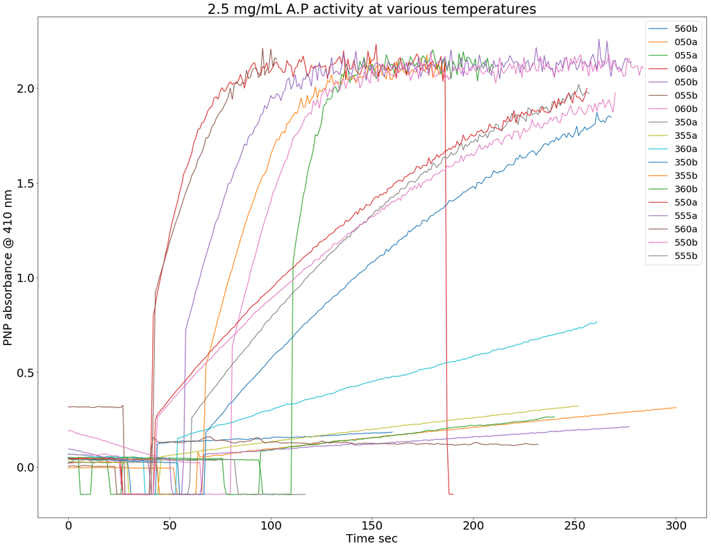

```python
import csv
import sys
sys.path.insert(0, 'process_csv/')
from process_csv import *
from scipy.stats import linregress
import numpy as np
import matplotlib.pyplot as plt
import requests
with open("dataset/ap_03072018.csv") as file:
    reader=csv.reader(file)
    data=list(reader)
header=data[0]
i=0
j=1
csvdict={}
while i<len(data[j]):
    csvdict[header[i]]=[]
    while j<len(data):
        csvdict[header[i]].append(data[j][i])
        j+=1
    j=1
    i+=1
for key,val in csvdict.items():
    val=list(map(float, [a for a in val if a]))
    csvdict[key]=val
for i in range(1,len(header)):
    plt.plot(csvdict[header[i]],label=header[i])
plt.xlabel("Time sec")
plt.ylabel("PNP absorbance @ 410 nm")
plt.title("2.5 mg/mL A.P activity at various temperatures")
plt.rcParams["figure.figsize"] = [26,20]
plt.rcParams.update({'font.size': 25})
plt.legend(prop={'size': 20})
```

```
[0.0, 3.0, 5.0] [2.4623999999999997, 0.8004, 0.7646999999999999] [0.03479999999999994, 0.04259999999999997, 0.033899999999999986]
[0.0, 3.0, 5.0] [2.9712, 0.08427000000000001, 0.0447] [0.7254, 0.00843, 0.0]
[0.0, 3.0, 5.0] [2.8296, 0.13574999999999998, 0.020961] [0.26760000000000006, 0.053849999999999995, 0.006842999999999999]
```

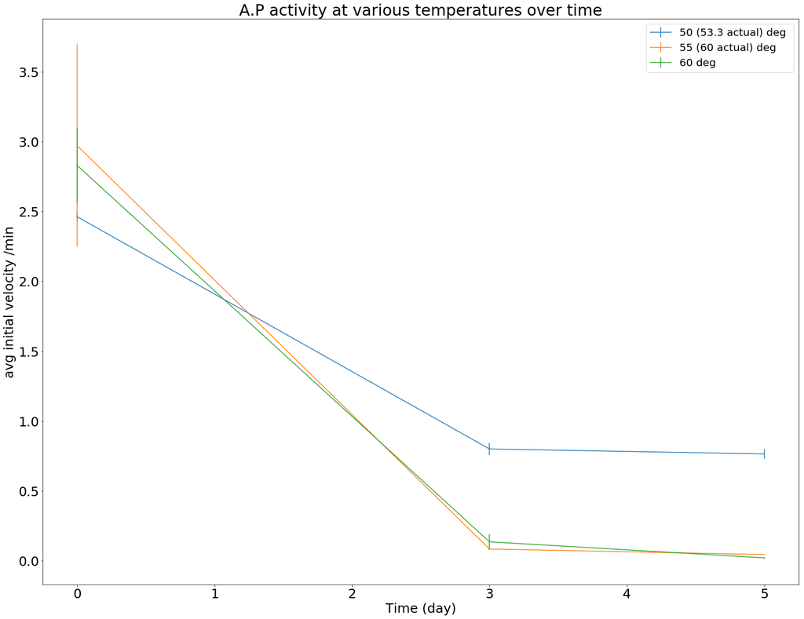

```python
import csv
import sys
import gc
sys.path.insert(0, 'process_csv/')
from process_csv import *
from scipy.stats import linregress
import numpy as np
import matplotlib.pyplot as plt
import requests
import pandas as pd
import random
import string
def Remove(duplicate):#remove duplicates from list
    final_list = []
    for num in duplicate:
        if num not in final_list:
            final_list.append(num)
    return final_list
with open("dataset/ap_03072018_init_vel.csv") as file:
    reader=csv.reader(file)
    data=list(reader)
header=data[0]
i=0
j=1
csvdict={}#csvdict module
while i<len(data[j]):
    csvdict[header[i]]=[]
    while j<len(data):
        csvdict[header[i]].append(data[j][i])
        j+=1
    j=1
    i+=1
for key,val in csvdict.items():
    val=list(map(float, [a for a in val if a]))
    csvdict[key]=val
csv_rowdict=defaultdict(list)#generate dict with first column as key, rest as values
time_head=csvdict['Time (day)']#timepoints
temp_head=header[1:4]#temp header
a=0
b=0
while a<len(time_head):
    while b<len(data[a][1:4]):
        csv_rowdict[time_head[a]].append(data[a+1][1:4][b])
        #print(data[a][1:4][b])
        b+=1
    b=0
    a+=1
for key,val in csv_rowdict.items():#convert all val in dict to float
    val=list(map(float, [a for a in val if a]))
    csv_rowdict[key]=val
val=list(map(float, [item for sublist in list(csv_rowdict.values()) for item in sublist]))#list of all initial velocity float in dict
ptval_dict=defaultdict(list)
for i in val:#generate dict with each initial velocity as key and corresponding [temp,time] as value. "val" is unique
    temp=[key for key, value in csvdict.items() if i in value].pop()
    time=[key for key, value in csv_rowdict.items() if i in value].pop()
    ptval_dict[i].append(temp)
    ptval_dict[i].append(time)
xval=[]
tempval=[]
meanval=[]
stdev=[]
for i in time_head:#group initial vel with same corresponding time,temp
    for j in temp_head:
        pts=[key for key, value in ptval_dict.items() if i in value and j in value]
        xval.append(i)#generate list of x values (time)
        tempval.append(j)#list of temperatures corresponding to time
        meanval.append(np.mean(pts))#list of mean of initial vel in each time,temp group
        stdev.append(np.std(pts))#list of stdev of initial vel in each time,temp group
to_plot=list(zip(xval,meanval,stdev,tempval))#zipped list of items to plot
to_plot=Remove(to_plot)#remove duplicates due to iteration
lentp=0#iterate thru to_plot=length of to_plot
tempheadlen=0#iterate thru list of temps=length of list of temp==3
plot_holderx=[]#list of xval to plot
plot_holdermean=[]#list of avg init vel to plot
plot_holderstdev=[]#list of stdev to plot
while tempheadlen<len(temp_head):
    plot_holderx=[]
    plot_holdermean=[]
    plot_holderstdev=[]
    lentp=0
    while lentp<len(to_plot):
        if to_plot[lentp][3]==temp_head[tempheadlen]:#pull all vals from to_plot with same temp
            plot_holderx.append(to_plot[lentp][0])#pull x values from to_plot zipped list
            plot_holdermean.append(to_plot[lentp][1])#pull avg values from to_plot zipped list
            plot_holderstdev.append(to_plot[lentp][2])#pull stdev values from to_plot zipped list
            lentp+=1
        else:#if "temp" at current to_plot index not equal to desired temp
            #print(False,temp_head[tempheadlen])
            lentp+=1
    plt.errorbar(plot_holderx,plot_holdermean,plot_holderstdev, label=temp_head[tempheadlen])
    print(plot_holderx,plot_holdermean,plot_holderstdev)
    tempheadlen+=1#move onto next temp
plt.xlabel("Time (day)")
plt.ylabel("avg initial velocity /min")
plt.title("A.P activity at various temperatures over time")
plt.rcParams["figure.figsize"] = [26,20]
plt.rcParams.update({'font.size': 25})
plt.legend(prop={'size': 20})
```